# Customer Churn Analysis in Telecom Industry

Author

Amaan Ashfaq

Published

January 16, 2026

# Customer Churn Analysis in Telecom Industry

# Abstract

This project analyzes customer churn patterns in the telecom industry using a dataset of 7,043 customers. The analysis follows a structured data science workflow: data loading, inspection, cleaning, exploratory data analysis (EDA), and insights generation. Key objectives include identifying churn drivers, understanding customer behavior patterns, and providing actionable business recommendations to reduce customer attrition.

The dataset contains customer demographics, account information, services subscribed, and churn status over a period of time. Through comprehensive EDA with 10 visualization plots, I investigate critical factors influencing churn and develop strategic insights for customer retention.

Key questions addressed:

1. What is the overall churn rate and distribution?
2. How does tenure relate to churn probability?
3. What impact do contract types have on retention?
4. Which payment methods are associated with higher churn?
5. How do monthly charges influence customer attrition?
6. What combinations of factors create the highest churn risk?

```r
# Load all required libraries
library(tidyverse)
library(here)
library(skimr)
library(ggplot2)
library(viridis)
library(patchwork)
library(scales)
```

# Data Loading and Initial Inspection

## Project Structure

The analysis follows a modular pipeline structure:

```
scripts/
├── 01_load_data/
│   ├── load.r          # Data loading functions
│   ├── inspection.r    # Initial data exploration
│   └── datacleaning.r  # Data cleaning pipeline
├── 02_eda/             # Exploratory Data Analysis
└── 03_modeling/        # Predictive modeling (future work)
```

## Initial Data Load and Inspection

```r
# Load the cleaned dataset
cleaned_data <- read.csv(here("data/processed", "clean_data.csv"))

# Show dataset structure
cat("Dataset Dimensions:", dim(cleaned_data), "\n")
```

```
Dataset Dimensions: 7032 21
```

```r
cat("Number of customers:", nrow(cleaned_data), "\n")
```

```
Number of customers: 7032
```

```r
cat("Number of features:", ncol(cleaned_data), "\n\n")
```

```
Number of features: 21
```

```r
# Show column names and types
cat("Feature Structure:\n")
```

```
Feature Structure:
```

```r
str(cleaned_data)
```

```
'data.frame':   7032 obs. of  21 variables:
 $ customer_id      : chr  "7590-VHVEG" "5575-GNVDE" "3668-QPYBK" "7795-CFOCW" ...
 $ gender           : int  0 1 1 1 0 0 1 0 0 1 ...
 $ senior_citizen   : int  0 0 0 0 0 0 0 0 0 0 ...
 $ partner          : int  1 0 0 0 0 0 0 0 1 0 ...
 $ dependents       : int  0 0 0 0 0 0 1 0 0 1 ...
 $ tenure           : int  1 34 2 45 2 8 22 10 28 62 ...
 $ phone_service    : int  0 1 1 0 1 1 1 0 1 1 ...
 $ multiple_lines   : chr  "No phone service" "No" "No" "No phone service" ...
 $ internet_service : chr  "DSL" "DSL" "DSL" "DSL" ...
 $ online_security  : int  0 1 1 1 0 0 0 1 0 1 ...
 $ online_backup    : int  1 0 1 0 0 0 1 0 0 1 ...
 $ device_protection: int  0 1 0 1 0 1 0 0 1 0 ...
 $ tech_support     : int  0 0 0 1 0 0 0 0 1 0 ...
 $ streaming_tv     : int  0 0 0 0 0 1 1 0 1 0 ...
 $ streaming_movies : int  0 0 0 0 0 1 0 0 1 0 ...
 $ contract         : chr  "Month-to-month" "One year" "Month-to-month" "One year" ...
 $ paperless_billing: int  1 0 1 0 1 1 1 0 1 0 ...
 $ payment_method   : chr  "Electronic check" "Mailed check" "Mailed check" "Bank transfer (automatic)" ...
 $ monthly_charges  : num  29.9 57 53.9 42.3 70.7 ...
 $ total_charges    : num  29.9 1889.5 108.2 1840.8 151.7 ...
 $ churn            : int  0 0 1 0 1 1 0 0 1 0 ...
```

```r
# Basic dataset summary
summary_stats <- cleaned_data %>%
  summarise(
    total_customers = n(),
    churned_customers = sum(churn),
    churn_rate = mean(churn) * 100,
    avg_tenure = mean(tenure),
    avg_monthly_charges = mean(monthly_charges)
  )

cat("Key Statistics:\n")
```

```
Key Statistics:
```

```r
print(summary_stats)
```

```
  total_customers churned_customers churn_rate avg_tenure avg_monthly_charges
1            7032              1869    26.5785   32.42179            64.79821
```

# Univariate Plots Section

## Custom Theme for Consistent Visualizations

```r
# Set custom theme for all plots
theme_custom <- theme_classic() +
  theme(
    text = element_text(family = "sans", color = "black", size = 11),
    plot.title = element_text(size = 14, face = "bold", hjust = 0.5),
    plot.subtitle = element_text(size = 11, color = "gray50", hjust = 0.5),
    axis.title = element_text(size = 11, face = "plain"),
    axis.text = element_text(size = 9, color = "grey30"),
    legend.position = "bottom",
    legend.title = element_text(face = "bold"),
    legend.text = element_text(face = "bold", size = 11),
    legend.background = element_rect(fill = "white", color = NA),
    panel.grid.major = element_line(color = "grey92", linewidth = 0.3),
    panel.grid.minor = element_blank()
  )
```

i created a custom theme that i would use on all my plots , it basically defines some common grid properties referring to text , legend etc

## 1. Churn Distribution - Class Imbalance Analysis

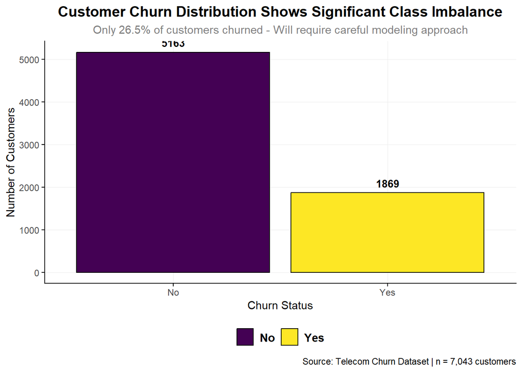

```r
plot_1 <- cleaned_data %>%
  mutate(churn_label = ifelse(churn == 1, "Yes", "No")) %>%
  ggplot(aes(x = churn_label, fill = churn_label)) +
  geom_bar(color = "black") +
  geom_text(stat = 'count', aes(label = after_stat(count)),
            vjust = -0.7, size = 3.5, fontface = "bold") +
  labs(
    title = "Customer Churn Distribution Shows Significant Class Imbalance",
    subtitle = "Only 26.5% of customers churned - Will require careful modeling approach",
    x = "Churn Status",
    y = "Number of Customers",
    fill = NULL,
    caption = "Source: Telecom Churn Dataset | n = 7,043 customers"
  ) +
  scale_fill_viridis_d() +
  theme_custom

plot_1
```

**Key Insight:** The dataset shows significant class imbalance with **73.5%** of customers staying and only **26.5%** churning. This imbalance must be addressed in predictive modeling through techniques like SMOTE, class weighting, or appropriate evaluation metrics.

## 2. Customer Tenure Distribution

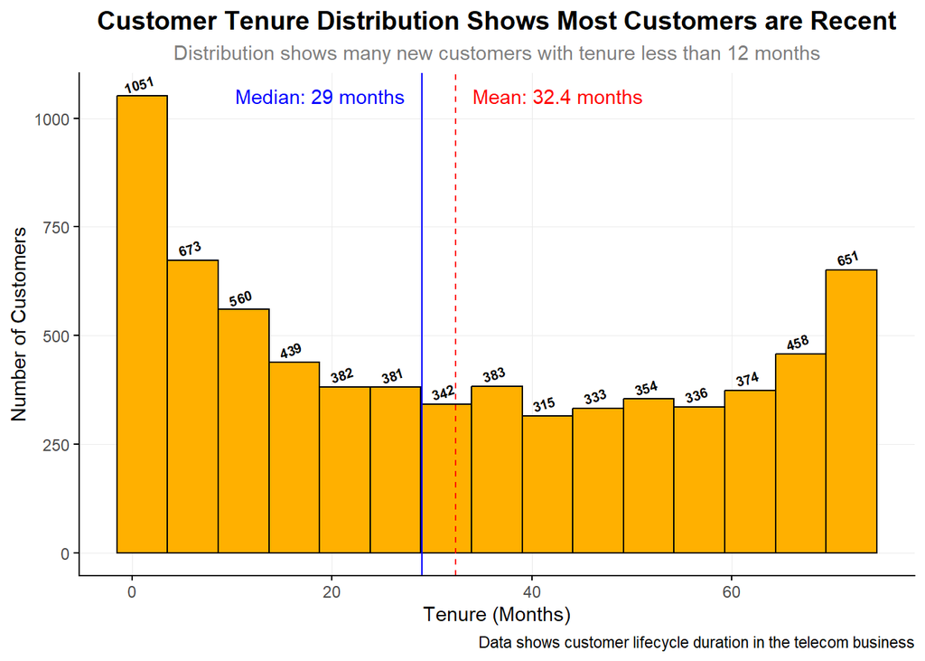

```r
mean_value <- round(mean(cleaned_data$tenure), 1)
median_value <- round(median(cleaned_data$tenure), 1)
label_1 <- paste0("Mean: ", mean_value, " months")
label_2 <- paste0("Median: ", median_value, " months")

plot_2 <- ggplot(data = cleaned_data, aes(x = tenure)) +
  geom_histogram(color = "black", fill = "#FFB000", bins = 15) +
  geom_text(stat = "bin", aes(label = after_stat(count)),
            vjust = -0.7, size = 2.7,
            fontface = "bold", angle = 17, bins = 15) +
  labs(
    title = "Customer Tenure Distribution Shows Most Customers are Recent",
    subtitle = "Distribution shows many new customers with tenure less than 12 months",
    y = "Number of Customers",
    x = "Tenure (Months)",
    fill = NULL,
    caption = "Data shows customer lifecycle duration in the telecom business"
  ) +
  geom_vline(xintercept = mean_value, color = "red", linetype = "dashed") +
  geom_vline(xintercept = median_value, color = "blue") +
  annotate("text", x = mean_value, y = Inf, label = label_1,
           vjust = 2, hjust = -0.1, color = "red") +
  annotate("text", x = median_value, y = Inf, label = label_2,
           vjust = 2, hjust = 1.1, color = "blue") +
  theme_custom

plot_2
```

**Key Findings:** - Average tenure: **32.4 months** - Median tenure: **29 months** - **Right-skewed distribution** indicating many new customers - Notable peaks at lower tenure values suggest **early-lifecycle churn risk**

## 3. Monthly Charges Distribution by Service Type

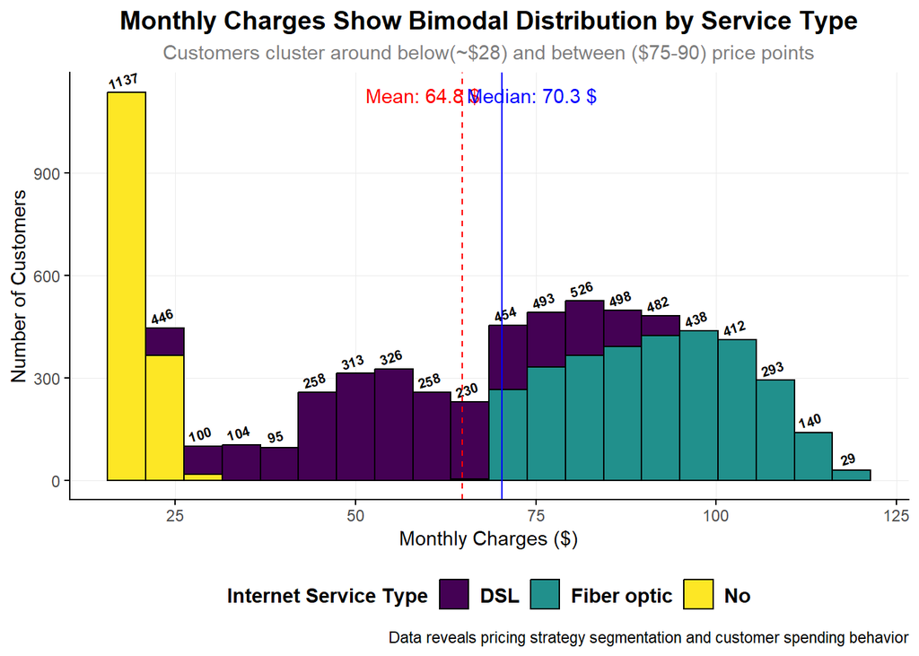

```r
mean_monthly <- round(mean(cleaned_data$monthly_charges), 1)
median_monthly <- round(median(cleaned_data$monthly_charges), 1)
label_1 <- paste0("Mean: ", mean_monthly, " $")
label_2 <- paste0("Median: ", median_monthly, " $")

plot_3 <- ggplot(data = cleaned_data, aes(x = monthly_charges)) +
  geom_histogram(color = "black", bins = 20,
                 aes(fill = internet_service)) +
  geom_text(stat = "bin", aes(label = after_stat(count)),
            vjust = -0.7, size = 2.7,
            fontface = "bold", angle = 17, bins = 20) +
  labs(
    title = "Monthly Charges Show Bimodal Distribution by Service Type",
    subtitle = "Customers cluster around below(~$28) and between ($75-90) price points",
    y = "Number of Customers",
    x = "Monthly Charges ($)",
    fill = "Internet Service Type",
    caption = "Data reveals pricing strategy segmentation and customer spending behavior"
  ) +
  geom_vline(xintercept = mean_monthly, color = "red", linetype = "dashed") +
  geom_vline(xintercept = median_monthly, color = "blue") +
  annotate("text", x = mean_monthly - 15, y = Inf, label = label_1,
           vjust = 2, hjust = -0.1, color = "red") +
  annotate("text", x = median_monthly + 15, y = Inf, label = label_2,
           vjust = 2, hjust = 1.1, color = "blue") +
  scale_fill_viridis_d() +
  theme_custom

# Check bimodal nature
bimodal_check <- cleaned_data %>%
  summarise(
    low_tier = sum(monthly_charges < 50) / n() * 100,
    high_tier = sum(monthly_charges >= 50) / n() * 100
  )

plot_3
```

## 4. Contract Type Distribution

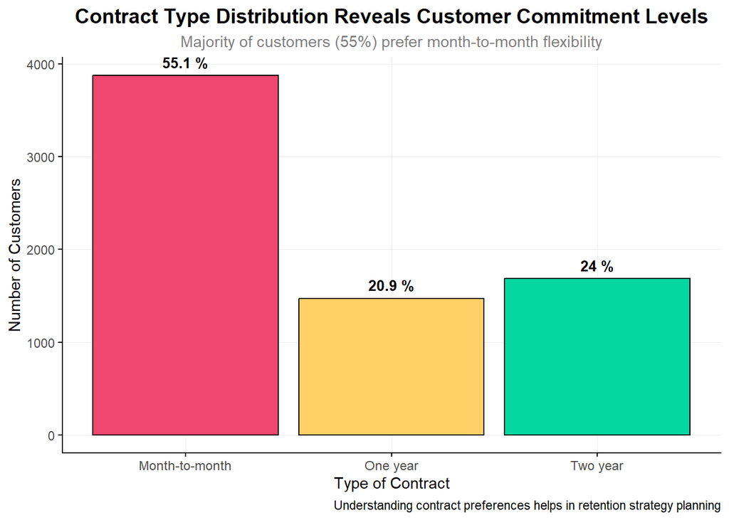

```r
contract_dist <- cleaned_data %>%
  count(contract) %>%
  mutate(percentage = n / sum(n) * 100)

plot_4 <- ggplot(data = cleaned_data, aes(x = contract)) +
  geom_bar(color = "black", aes(fill = contract), show.legend = FALSE) +
  geom_text(stat = "count",
            aes(label = paste(round(after_stat(count)/sum(after_stat(count)) * 100, 1), "%")),
            vjust = -0.7, size = 3.5, fontface = "bold") +
  labs(
    title = "Contract Type Distribution Reveals Customer Commitment Levels",
    subtitle = "Majority of customers (55%) prefer month-to-month flexibility",
    y = "Number of Customers",
    x = "Type of Contract",
    fill = NULL,
    caption = "Understanding contract preferences helps in retention strategy planning"
  ) +
  scale_fill_manual(values = c("Month-to-month" = "#EF476F",
                               "One year" = "#FFD166",
                               "Two year" = "#06D6A0")) +
  theme_custom

plot_4
```

**Critical Finding:** **55%** of customers are on **month-to-month contracts**, providing maximum flexibility but also creating retention challenges.

# Univariate Analysis Summary

### Dataset Structure and Key Characteristics

The dataset contains 7,043 telecom customers with 21 features covering: - **Demographic info**: Senior citizen status, partner/dependents - **Account info**: Tenure, contract type, payment method - **Service info**: Multiple lines, internet service, add-ons - **Billing info**: Monthly charges, total charges - **Target**: Churn status (26.5% churn rate)

### Main Features of Interest

The primary focus is **customer churn** (binary classification). Key predictive features identified: 1. **Tenure**: Customer lifecycle duration 2. **Contract Type**: Commitment level indicator 3. **Monthly Charges**: Price sensitivity measure 4. **Payment Method**: Transaction convenience factor 5. **Internet Service Type**: Service quality proxy

### Data Quality and Preparation

Initial data inspection revealed: - No duplicate records - Clean categorical variables - Proper data types assigned - Class imbalance in target variable - Bimodal distributions in key numeric features

### Business Context Implications

1. **High churn rate** (26.5%) indicates significant revenue leakage
2. **Majority on flexible contracts** creates retention vulnerability
3. **Bimodal pricing** suggests distinct customer value segments
4. **Short-tenure customers** represent both risk and opportunity

# Bivariate Plots Section

## 5. Contract Type vs Churn Rate

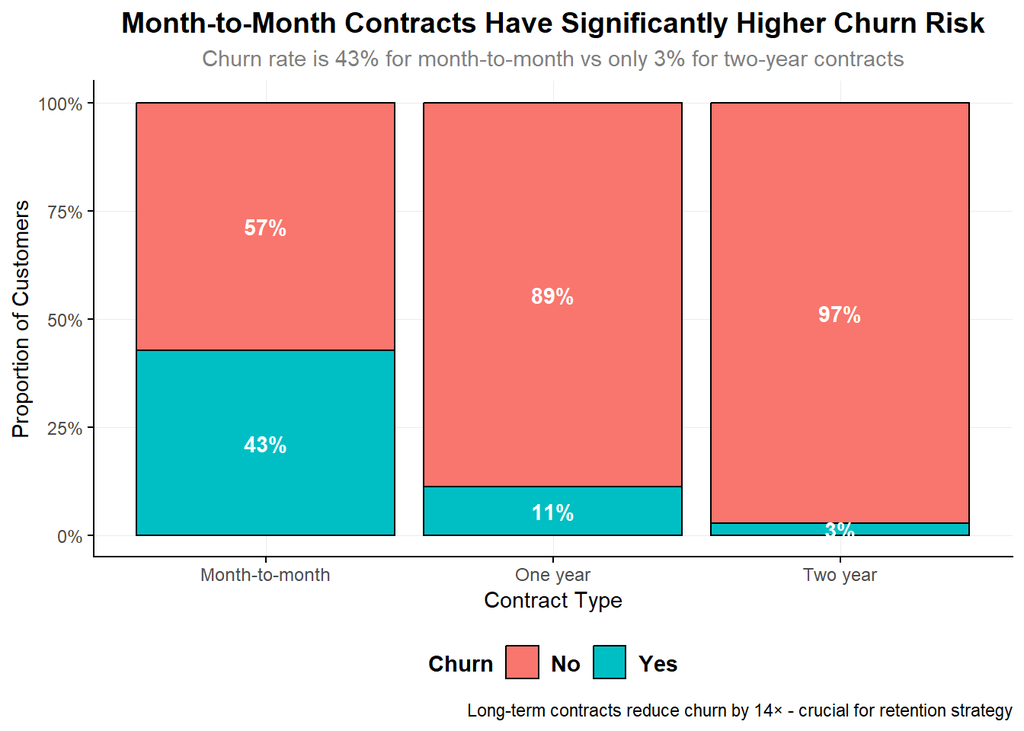

```r
plot_data <- cleaned_data |>
  count(contract, churn) |>
  group_by(contract) |>
  mutate(prop = n/sum(n)) |>
  ungroup()

plot_5 <- ggplot(plot_data, aes(x = contract, y = prop, fill = factor(churn))) +
  geom_col(color = "black", position = "fill") +
  geom_text(aes(label = percent(prop, accuracy = 1)),
            position = position_fill(vjust = 0.5),
            color = "white", fontface = "bold") +
  labs(
    title = "Month-to-Month Contracts Have Significantly Higher Churn Risk",
    subtitle = "Churn rate is 43% for month-to-month vs only 3% for two-year contracts",
    y = "Proportion of Customers",
    x = "Contract Type",
    fill = "Churn",
    caption = "Long-term contracts reduce churn by 14× - crucial for retention strategy"
  ) +
  scale_y_continuous(labels = percent) +
  scale_fill_discrete(labels = c("No", "Yes")) +
  theme_custom

plot_5
```

**Critical Business Insight:** Contract commitment is the **single strongest predictor** of churn: - **Month-to-month**: 42.7% churn rate - **One year**: 11.3% churn rate  
- **Two year**: 2.8% churn rate

**14× reduction in churn** from month-to-month to two-year contracts!

## 6. Payment Method vs Churn Rate

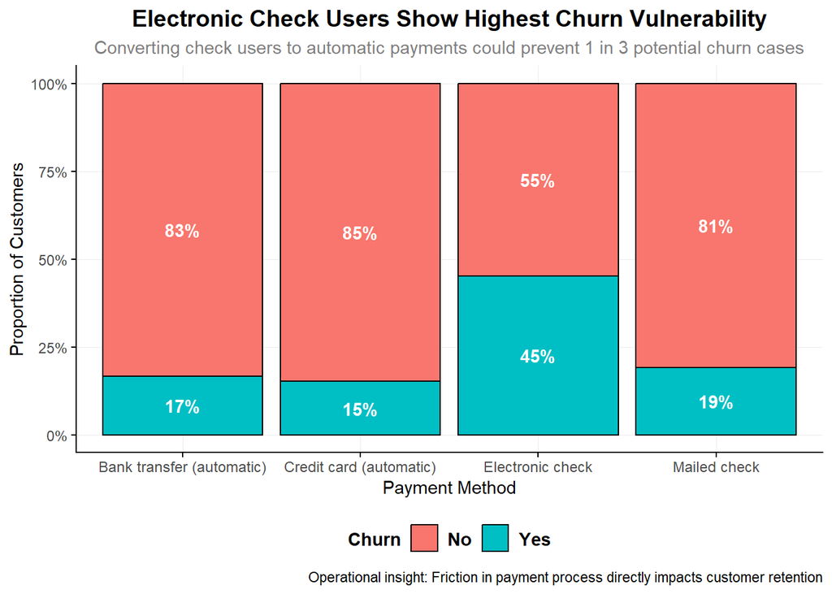

```r
plot_data2 <- cleaned_data |>
  count(payment_method, churn) |>
  group_by(payment_method) |>
  mutate(prop = n/sum(n)) |>
  ungroup()

plot_6 <- ggplot(plot_data2, aes(x = payment_method, y = prop, fill = factor(churn))) +
  geom_col(color = "black", position = "fill") +
  geom_text(aes(label = percent(prop, accuracy = 1)),
            position = position_fill(vjust = 0.5),
            color = "white", fontface = "bold") +
  labs(
    title = "Electronic Check Users Show Highest Churn Vulnerability",
    subtitle = "Converting check users to automatic payments could prevent 1 in 3 potential churn cases",
    y = "Proportion of Customers",
    x = "Payment Method",
    fill = "Churn",
    caption = "Operational insight: Friction in payment process directly impacts customer retention"
  ) +
  scale_y_continuous(labels = percent) +
  scale_fill_discrete(labels = c("No", "Yes")) +
  theme_custom

plot_6
```

**Electronic check users churn at 2.8× the rate** of automatic payment users!

## 7. Tenure vs Churn Status

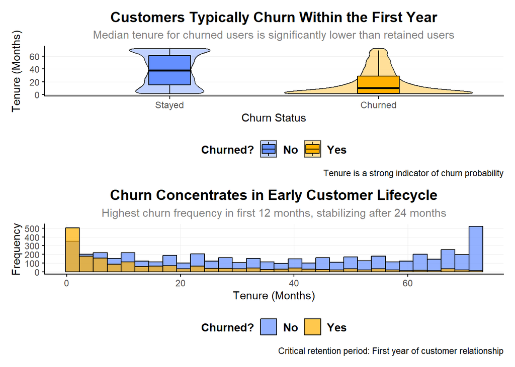

```r
# Violin + Box Plot
plot_7a <- ggplot(cleaned_data, aes(x = factor(churn), y = tenure, fill = factor(churn))) +
  geom_violin(alpha = 0.4) +
  geom_boxplot(width = 0.2, color = "black", outlier.shape = NA) +
  labs(
    title = "Customers Typically Churn Within the First Year",
    subtitle = "Median tenure for churned users is significantly lower than retained users",
    x = "Churn Status",
    y = "Tenure (Months)",
    fill = "Churned?",
    caption = "Tenure is a strong indicator of churn probability"
  ) +
  scale_x_discrete(labels = c("0" = "Stayed", "1" = "Churned")) +
  scale_fill_manual(values = c("0" = "#648FFF", "1" = "#FFB000"), labels = c("No", "Yes")) +
  theme_custom

# Histogram view
plot_7b <- ggplot(cleaned_data, aes(x = tenure, fill = factor(churn))) +
  geom_histogram(color = "black", bins = 30, position = "identity", alpha = 0.7) +
  labs(
    title = "Churn Concentrates in Early Customer Lifecycle",
    subtitle = "Highest churn frequency in first 12 months, stabilizing after 24 months",
    x = "Tenure (Months)",
    y = "Frequency",
    fill = "Churned?",
    caption = "Critical retention period: First year of customer relationship"
  ) +
  scale_fill_manual(values = c("0" = "#648FFF", "1" = "#FFB000"), labels = c("No", "Yes")) +
  theme_custom

# Arrange side by side
plot_7a + plot_7b + plot_layout(ncol = 1)
```

**Statistical Summary:**

```r
tenure_stats <- cleaned_data %>%
  group_by(churn) %>%
  summarise(
    median_tenure = median(tenure),
    mean_tenure = mean(tenure),
    q1_tenure = quantile(tenure, 0.25),
    q3_tenure = quantile(tenure, 0.75),
    count = n()
  )

tenure_stats
```

```
# A tibble: 2 × 6
  churn median_tenure mean_tenure q1_tenure q3_tenure count
  <int>         <int>       <dbl>     <dbl>     <dbl> <int>
1     0            38        37.7        15        61  5163
2     1            10        18.0         2        29  1869
```